# PM2.5 Emissions - Case Study

Sarthak Dasadia

September 10, 2016

# Goal

Study emission of fine particulate matter (PM2.5) and perform exploratory analysis to yaddress questions like: How emission has changed over time? What are the harmful sources?

## Introduction

Fine particulate matter (PM2.5) is an ambient air pollutant for which there is strong evidence that it is harmful to human health. In the United States, the Environmental Protection Agency (EPA) is tasked with setting national ambient air quality standards for fine PM and for tracking the emissions of this pollutant into the atmosphere. Approximatly every 3 years, the EPA releases its database on emissions of PM2.5. This database is known as the National Emissions Inventory (NEI). You can read more information about the NEI at the EPA National Emissions Inventory web site.

For each year and for each type of PM source, the NEI records how many tons of PM2.5 were emitted from that source over the course of the entire year. The data that you will use for this assignment are for 1999, 2002, 2005, and 2008.

## Data

The data file contains two files:

PM2.5 Emissions Data (𝚜𝚞𝚖𝚖𝚊𝚛𝚢𝚂𝙲𝙲_𝙿𝙼𝟸𝟻.𝚛𝚍𝚜): This file contains a data frame with all of the PM2.5 emissions data for 1999, 2002, 2005, and 2008. For each year, the table contains number of tons of PM2.5 emitted from a specific type of source for the entire year. Here are the first few rows.

```r
NEI <- readRDS("summarySCC_PM25.rds")
SCC <- readRDS("Source_Classification_Code.rds")
data <- merge(NEI,SCC,by="SCC") # Mergered Data Set

head(NEI)
```

```
##     fips      SCC Pollutant Emissions  type year
## 4  09001 10100401  PM25-PRI    15.714 POINT 1999
## 8  09001 10100404  PM25-PRI   234.178 POINT 1999
## 12 09001 10100501  PM25-PRI     0.128 POINT 1999
## 16 09001 10200401  PM25-PRI     2.036 POINT 1999
## 20 09001 10200504  PM25-PRI     0.388 POINT 1999
## 24 09001 10200602  PM25-PRI     1.490 POINT 1999
```

- 𝚏𝚒𝚙𝚜: A five-digit number (represented as a string) indicating the U.S. county
- 𝚂𝙲𝙲: The name of the source as indicated by a digit string (see source code classification table)
- 𝙿𝚘𝚕𝚕𝚞𝚝𝚊𝚗𝚝: A string indicating the pollutant
- 𝙴𝚖𝚒𝚜𝚜𝚒𝚘𝚗𝚜: Amount of PM2.5 emitted, in tons
- 𝚝𝚢𝚙𝚎: The type of source (point, non-point, on-road, or non-road)
- 𝚢𝚎𝚊𝚛: The year of emissions recorded

Source Classification Code Table (𝚂𝚘𝚞𝚛𝚌𝚎_𝙲𝚕𝚊𝚜𝚜𝚒𝚏𝚒𝚌𝚊𝚝𝚒𝚘𝚗_𝙲𝚘𝚍𝚎.𝚛𝚍𝚜): This table provides a mapping from the SCC digit strings in the Emissions table to the actual name of the PM2.5 source. The sources are categorized in a few different ways from more general to more specific and you may choose to explore whatever categories you think are most useful. For example, source “10100101” is known as “Ext Comb /Electric Gen /Anthracite Coal /Pulverized Coal”.

## Have total emissions from PM2.5 decreased in the United States from 1999 to 2008?

Find the mean PM2.5 emission from all sources from 1999 to 2008 and plot it.

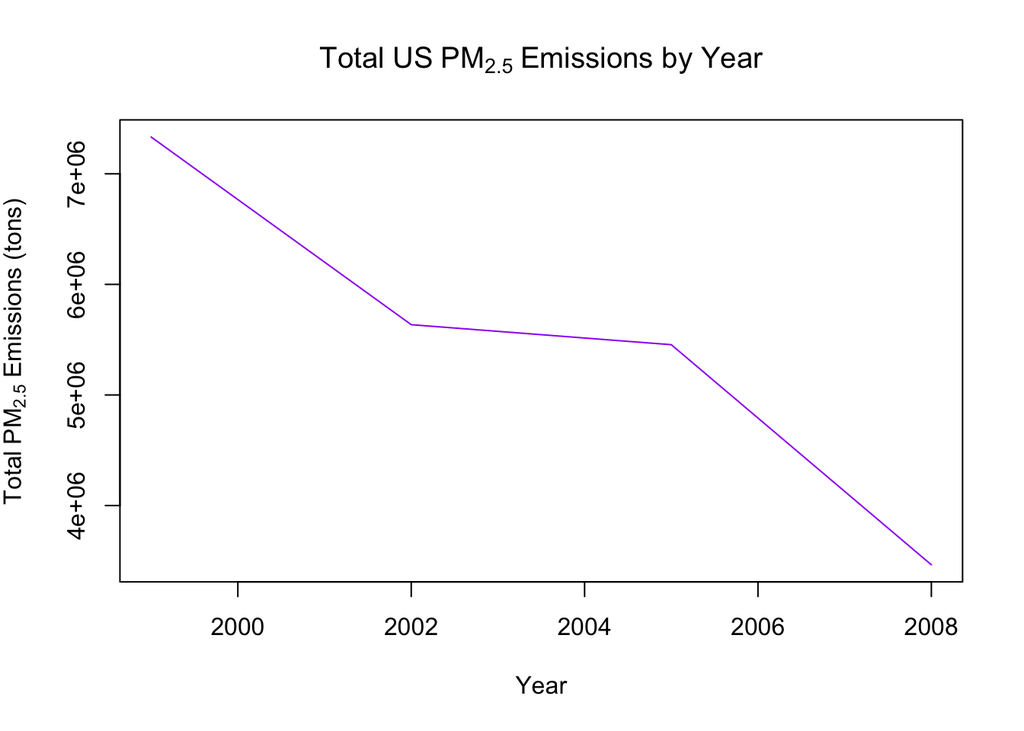

```r
meanpm <- tapply(NEI$Emissions, NEI$year, sum)

plot(names(meanpm),meanpm,type="l", xlab = "Year", ylab = expression ("Total" ~ PM[2.5] ~"Emissions (tons)"),
     main = expression("Total US" ~ PM[2.5] ~ "Emissions by Year"), col="Purple")
```

It looks like the mean PM2.5 (calculated from all sources) emission has gone down from 1999 to 2008.

## Have total emissions from PM2.5 decreased in the Baltimore City, Maryland (𝚏𝚒𝚙𝚜 == “𝟸𝟺𝟻𝟷𝟶”) from 1999 to 2008?

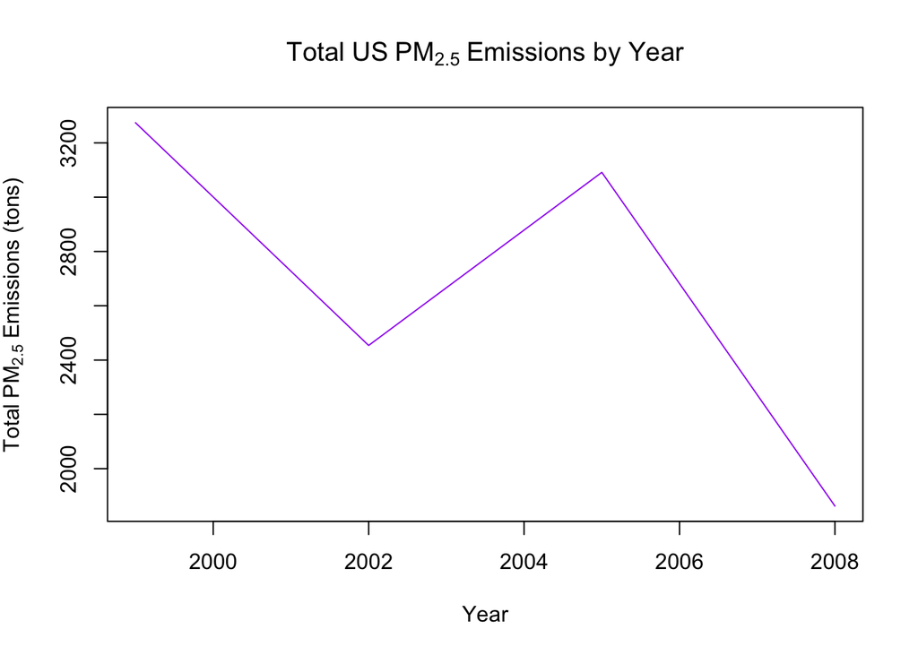

```r
baltimore <- NEI[NEI$fips == "24510",]
baltmean <- tapply(baltimore$Emissions, baltimore$year, sum)

plot(names(baltmean),baltmean,type="l", xlab = "Year", ylab = expression ("Total" ~ PM[2.5] ~"Emissions (tons)"),
     main = expression("Total US" ~ PM[2.5] ~ "Emissions by Year"), col="Purple")
```

The mean PM2.5 emission from all sources went down from 1999 to 2002, then increased little bit between 2002 to 2005 and decreased again from 2005 to 2008. In general, the PM2.5 emission decreased in the Baltimore City from 1999 to 2008.

## Which of the four sources have seen decreases in emissions from 1999–2008 for Baltimore City? Which have seen increases in emissions from 1999–2008?

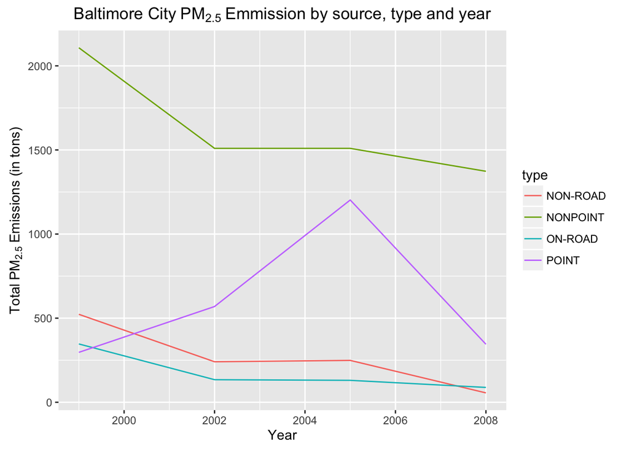

```r
library(ggplot2)

balt_year_source <- aggregate(Emissions ~ year + type, baltimore, sum)

qplot(year, Emissions, data=balt_year_source, color=type, geom ="line") +
        ggtitle(expression("Baltimore City" ~ PM[2.5] ~ "Emmission by source, type and year")) +
        xlab("Year") + ylab(expression("Total" ~ PM[2.5] ~ "Emissions (in tons)"))
```

Of the four types of sources (Point, Non-Point, On-Road, None-Road), the mean emission from Non-Road, Non-Point and On-Road have decreased while the emission from Point sources have increased little bit.

## Across the United States, how have emissions from coal combustion-related sources changed from 1999–2008?

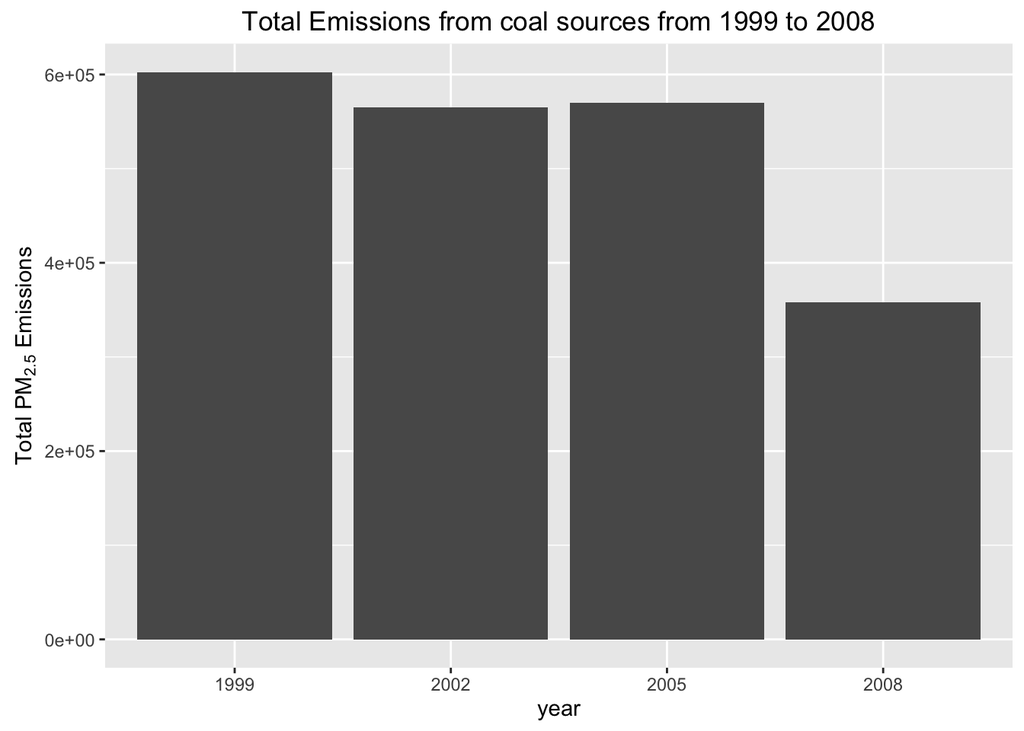

```r
coal = grepl("coal", data$Short.Name, ignore.case=TRUE)
coaldata = data[coal,]

emission <- aggregate(Emissions ~ year, coaldata, sum)

g <- ggplot(emission, aes(factor(year), Emissions))
g <- g + geom_bar(stat="identity") +
        xlab("year") +
        ylab(expression('Total PM'[2.5]*" Emissions")) +
        ggtitle('Total Emissions from coal sources from 1999 to 2008')
print(g)
```

Across the US, the PM2.5 emission from coal combusion-related sources are on trend to decrease.

## How have emissions from motor vehicle sources changed from 1999–2008 in Baltimore City?

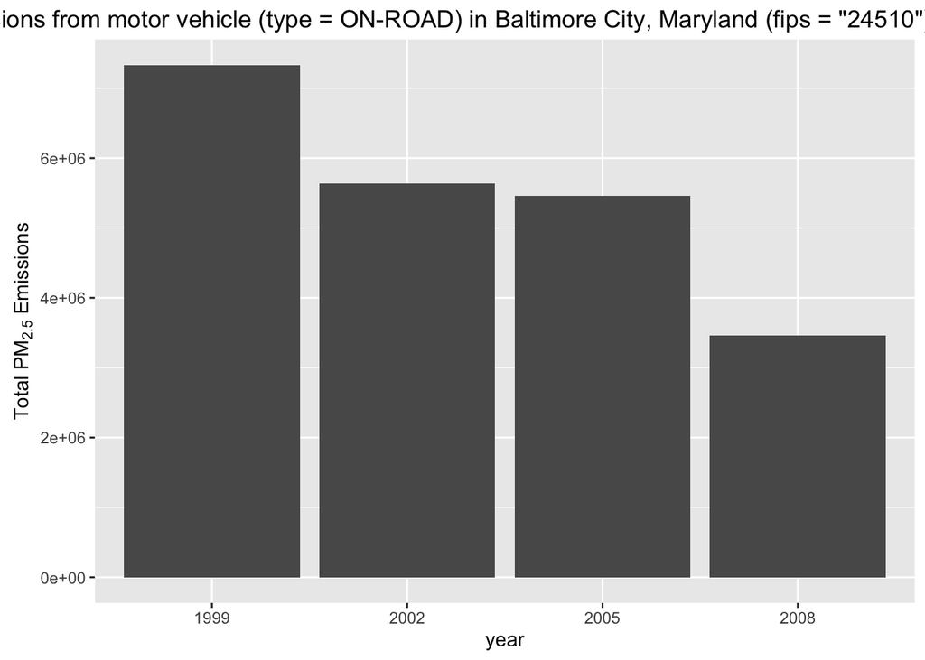

```r
motor <- NEI[NEI$fips=="24510" & NEI$type=="ON-ROAD",  ]
emission_motor <- aggregate(Emissions ~ year, data, sum)

g <- ggplot(emission_motor, aes(factor(year), Emissions))
g <- g + geom_bar(stat="identity") +
        xlab("year") +
        ylab(expression('Total PM'[2.5]*" Emissions")) +
        ggtitle('Total Emissions from motor vehicle (type = ON-ROAD) in Baltimore City, Maryland (fips = "24510") from 1999 to 2008')
print(g)
```

The motor emission in Baltimore City has decreased from 1999 to 2008.

## Which city has seen greater changes over time in motor vehicle emissions (Baltimore or Los Angeles)?

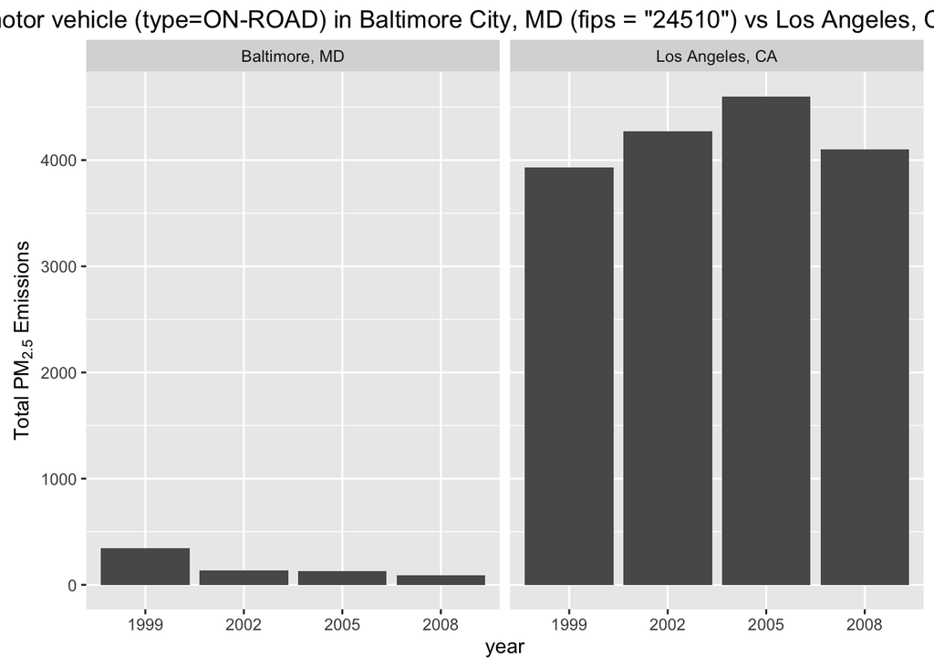

```r
motor <- NEI[(NEI$fips=="24510" | NEI$fips == "06037") & NEI$type=="ON-ROAD", ]

agg <- aggregate(Emissions ~ year + fips, motor, sum)
agg$fips[agg$fips=="24510"] <- "Baltimore, MD"
agg$fips[agg$fips=="06037"] <- "Los Angeles, CA"

g <- ggplot(agg, aes(factor(year), Emissions))
g <- g + facet_grid(. ~ fips)
g <- g + geom_bar(stat="identity")  +
        xlab("year") +
        ylab(expression('Total PM'[2.5]*" Emissions")) +
        ggtitle('Total Emissions from motor vehicle (type=ON-ROAD) in Baltimore City, MD (fips = "24510") vs Los Angeles, CA (fips = "06037")  1999-2008')
print(g)
```

The motor vehicle emission in Baltimore City has decreased over time.